# Assignment 1 ExData_Plotting1

Stefan Schmager

November 11, 2015

# Introduction

This assignment uses data from the [UC Irvine Machine Learning Repository](http://archive.ics.uci.edu/ml/), a popular repository for machine learning datasets. In particular, I will be using the “Individual household electric power consumption Data Set” which is made available on the course web site:

- **Dataset**: [Household Power Consumption](https://d396qusza40orc.cloudfront.net/exdata%2Fdata%2Fhousehold_power_consumption.zip)
- **Description**: Measurements of electric power consumption in one household with a one-minute sampling rate over a period of almost 4 years. Different electrical quantities and some sub-metering values are available.
- **Variables**: The following descriptions of the 9 variables in the dataset are taken from the [UCI web site](https://archive.ics.uci.edu/ml/datasets/Individual+household+electric+power+consumption)
- *Date*: Date in format dd/mm/yyyy
- *Time*: time in format hh:mm:ss
- *Global Active Power*: household global minute-averaged active power (in kilowatt)
- *Global Reactive Power*: household global minute-averaged reactive power (in kilowatt)
- *Voltage*: minute-averaged voltage (in volt)
- Global_intensity: household global minute-averaged current intensity (in ampere)
- *Sub-metering 1*: energy sub-metering No. 1 (in watt-hour of active energy). It corresponds to the kitchen, containing mainly a dishwasher, an oven and a microwave (hot plates are not electric but gas powered).
- *Sub-metering 2*: energy sub-metering No. 2 (in watt-hour of active energy). It corresponds to the laundry room, containing a washing-machine, a tumble-drier, a refrigerator and a light.
- *Sub-metering 3*: energy sub-metering No. 3 (in watt-hour of active energy). It corresponds to an electric water-heater and an air-conditioner.

# Loading the data

The dataset has 2,075,259 rows and 9 columns. I will only be using a data subset from the dates 2007-02-01 and 2007-02-02.

You may find it useful to convert the Date and Time variables to Date/Time classes in R using the strptime() and as.Date() functions.

Note that in this dataset missing values are coded as ?.

```r
# Load package
library(dplyr)
```

```r
# Set working directory, weblink of data set, zip-folder name, and data file name
setwd("C:/Users/Stefan/Google Drive/Coursera/05_Exploratory Data Analysis/ExData_Plotting1")
data.source <- "https://d396qusza40orc.cloudfront.net/exdata%2Fdata%2Fhousehold_power_consumption.zip"
zip.folder  <- "household_power_consumption.zip"
data.file   <- "household_power_consumption.txt"

# Download zip file if not already done so
if (!file.exists(zip.folder)) {
      download.file(data.source, zip.folder)
}

# Read data file that is extracted from zip folder
data        <- read.table(unz(zip.folder, data.file),
                          header = T,
                          sep = ";",
                          colClasses = c(rep("character", 2),
                                         rep("numeric",   7)),
                          na.strings = "?") %>%

      # Convert dates to "Date" class
      mutate(Date = as.Date(Date, "%d/%m/%Y")) %>%

      # Filter rows with relevany dates
      filter(Date >= "2007-02-01" & Date <= "2007-02-02")

# Convert date times (that were concatenated from Date and Time variable) to "PISIXlt" class
data$DateTime     <- strptime(paste(as.character(data$Date), data$Time), "%Y-%m-%d %H:%M:%S")
```

# Assignment Goal: Replicating Plots

Our overall goal here is simply to examine how household energy usage varies over a 2-day period in February, 2007. Your task is to reconstruct the following plots below, all of which were constructed using the base plotting system.

For each plot the following directions were given:

1. Construct the plot and save it to a PNG file with a width of 480 pixels and a height of 480 pixels.
2. Name each of the plot files as plot1.png, plot2.png, etc.
3. Create a separate R code file (plot1.R, plot2.R, etc.) that constructs the corresponding plot, i.e. code in plot1.R constructs the plot1.png plot.
4. Add the PNG file and R code file to the top-level folder of your git repository. There should be four PNG files and four R code files, a total of eight files in the top-level folder of the repo.

The code for reading the data is displayed above and will not be repeated again.

# Assignment

## Plot 1

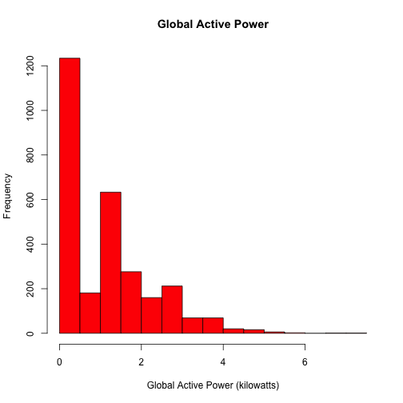

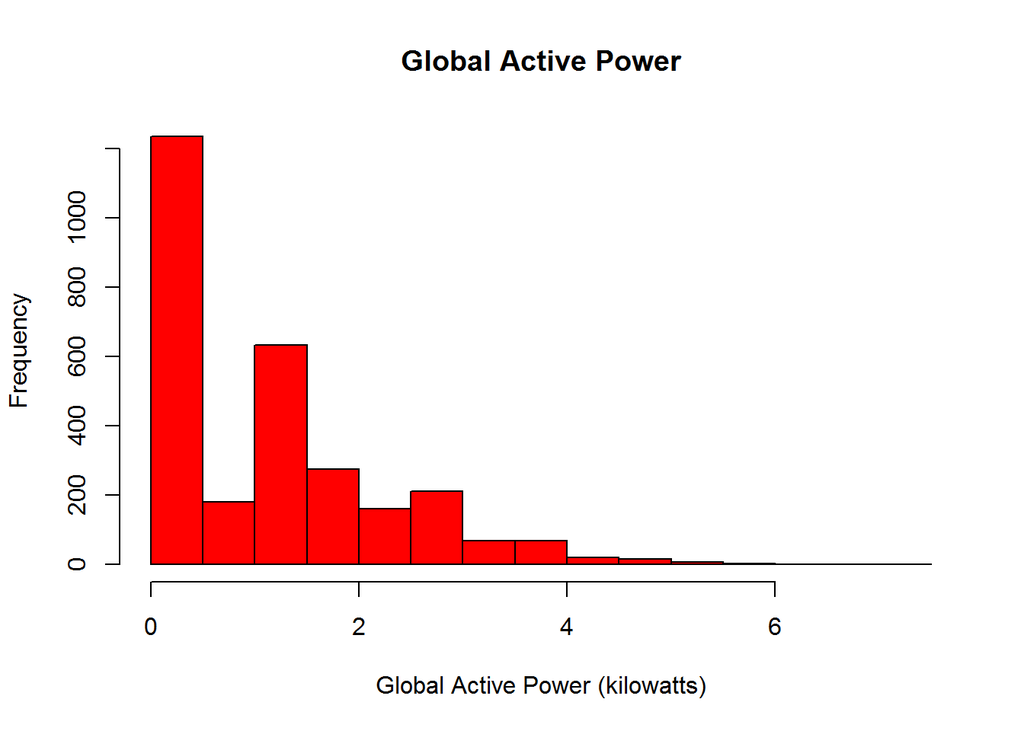

```r
hist(data$Global_active_power,
     col = "red",
     main = "Global Active Power",
     xlab = "Global Active Power (kilowatts)")
```

```r
dev.copy(png, file = "plot1.png")
```

```r
dev.off()
```

## Plot 2

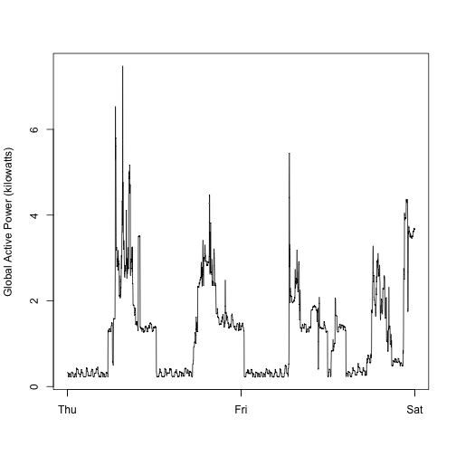

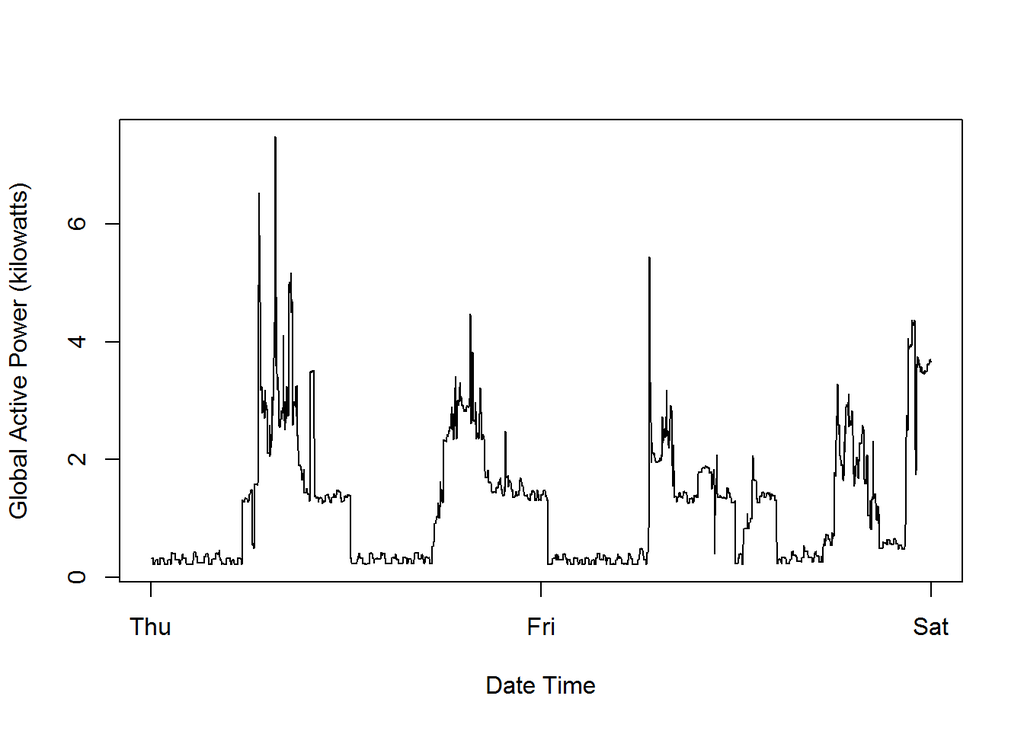

```r
with(data,
     plot(DateTime, Global_active_power,
          type = "l",
          xlab = "Date Time",
          ylab = "Global Active Power (kilowatts)"))
```

```r
dev.copy(png, file = "plot2.png")
```

```r
dev.off()
```

## Plot 3

[figure not shown]

```r
png(filename = "plot3.png")
with(data, {
      plot(DateTime, Sub_metering_1, col = "black",
           type = "l",
           xlab = "Date Time",
           ylab = "Energy Sub Metering (watt-hour)")
      lines(DateTime, Sub_metering_2, col = "red")
      lines(DateTime, Sub_metering_3, col = "blue")
legend("topright",
       lty = 1,
       col    = c("black",          "red",            "blue"),
       legend = c("Sub metering 1", "Sub metering 2", "Sub metering 3"))
})

dev.off()
```

## Plot 4

[figure not shown]

```r
png(filename = "plot4.png")

with(data, {

      par(mfrow = c(2, 2))

      # top-left
      plot(DateTime, Global_active_power,
           type = "l",
           xlab = "Date Time",
           ylab = "Global Active Power (kilowatts)")

      # top-right
      plot(DateTime, Voltage,
           type = "l",
           xlab = "Date Time",
           ylab = "Voltage (volt)")

      # bottom-left
      plot(DateTime, Sub_metering_1, col = "black",
           type = "l",
           xlab = "Date Time",
           ylab = "Energy Sub Metering (watt-hour)")
      lines(DateTime, Sub_metering_2, col = "red")
      lines(DateTime, Sub_metering_3, col = "blue")
      legend("topright",
             bty = "n",
             lty = 1,
             col    = c("black",          "red",            "blue"),
             legend = c("Sub metering 1", "Sub metering 2", "Sub metering 3"))

      # bottom-right
      plot(DateTime, Global_reactive_power,
           type = "l",
           xlab = "Date Time",
           ylab = "Global Reactive Power (kilowatts)")

})

dev.off()
```

# Assignments Peer Reviewing

Once the assigment had been finished, the git repository was push to GitHub so that the GitHub version of the repository is up to date for subsequent peer evaluation.

The course – that the assignment is part of – is about exploratory graphs, understanding the data, and developing strategies. Here’s a good quote from a swirl lesson about exploratory graphs: “They help us find patterns in data and understand its properties. They suggest modeling strategies and help to debug analyses. We **DON’T** use exploratory graphs to communicate results.”

The rubrics should always be interpreted in that context.

As you do your evaluation, please keep an open mind and focus on the positive. The goal is not to deduct points over small deviations from the requirements or for legitimate differences in implementation styles, etc. Look for ways to give points when it’s clear that the submitter has given a good faith effort to do the project, and when it’s likely that they’ve succeeded. Most importantly, it’s okay if a person did something differently from the way that you did it. The point is not to see if someone managed to match your way of doing things, but to see if someone objectively accomplished the task at hand.

To that end, the following things should be kept in mind:

- DO:
- Review the source code.
- Keep an open mind and focus on the positive.
- When in doubt, err on the side of giving too many points, rather than giving too few.
- Ask yourself if a plot might answer a question for the person who created it.
- Remember that not everyone has the same statistical background and knowledge.
- DON’T:
- Deduct just because you disagree with someone’s statistical methods.
- Deduct just because you disagree with someone’s plotting methods.
- Deduct based on aesthetics.